# Minimalist Approach for Deciphering the Ecophysiology of Human Gut Microbes

Transcriptional activity of MDb-MM

Sudarshan A. Shetty

Thu Jul 15 09:31:53 2021

## Load pkgs

```r
### Setup anlaysis
suppressPackageStartupMessages({
  library(syncomR)
  library(dplyr)
  library(tidyr)
  library(ggpubr)
  library(scales)
  library(knitr)
  library(reshape2)
  library(ggrepel)
  library(patchwork)
  library(qgraph)
  library(DESeq2)
  library(stringr)
  library(edgeR)
  library(ggridges)
})
#BiocManager::install("DESeq2")
#BiocManager::install("edgeR")

### Assign colors to key variables
fasting_cols <- c("#1b9e77", "#d95f02", "#7570b3")

fer_cols <- c(`Bioreactor A`= "#b2182b",
              `Bioreactor B`="#2166ac",
              `Bioreactor C` = "#35978f")

colorsSCFA <- c(Acetate = "#CBD588", Propionate = "#5F7FC7",
                Butyrate = "orange", Isobutyrate= "#DA5724",
                Formate ="#508578", Lactate = "#CD9BCD",
                Glucose = "#AD6F3B", Fructose = "#673770",
                Succinate = "#D14285")
```

```r
dir.create("ms/modules")
```

```r
dir.create("ms/modules/figures")
dir.create("ms/modules/tables")
```

## Transcriptional behavior of MDb-MM

### Gut metabolic module

We used the gut metabolic module framework in which we used metabolic module expression for short-chain fatty acids pathways. #### Functional ordination

```r
ps1 <- SyncomFiltData
mods <- readRDS("../data/mdbmm_gmm_out_apr2020.rds")

modsDF <- cbind(mods@annotation, slot(mods, "abundance"))

#modsDF
curatedGMM_names <- read.table("../data/curated_gmm_trophic_levels.txt", header=T, sep="\t")
#head(curatedGMM_names)

fil_list <- modsDF$Module
curatedGMM_names_filt <- filter(curatedGMM_names, curatedGMM_names$module_id %in% fil_list)

#dim(curatedGMM_names_filt)
#curatedGMM_names_filt$V1
colnames(curatedGMM_names_filt) <- c("Module", "Names", colnames(curatedGMM_names_filt)[3:10])

module_df <- merge(modsDF, curatedGMM_names_filt, by.x="Module")

mods_sum2 <- modsDF %>% group_by(Module) %>% summarize_if(is.numeric,sum,na.rm = TRUE)

mods_sum <- as.data.frame(mods_sum2)
rownames(mods_sum) <- mods_sum$Module
#mods_sum.vfa <- as.data.frame(filter(mods_sum.vfa, colnames(mods_sum.vfa) %in% rownames(hplc)))
colnames(mods_sum) <- c("Module","F8T176","F6T248","F8T152","F6T74.5", "F8T52","F5T240","F5T264", "F8T24","F5T52","F6T24","F8T48","F5T248","F5T56","F5T32","F6T240","F6T48","F8T28","F6T28","F6T264","F8T264","F8T240","F5T74.5" , "F5T152" ,"F5T176","F8T74.5", "F6T56","F5T24","F8T32","F6T52","F8T56","F6T32","F5T28","F6T152" ,"F5T48","F8T248","F6T176")
mods_sum <- as.data.frame(t(mods_sum[,-1]))
head(mods_sum)
```

[output not shown]

[output cut: 57 more lines]

[output not shown]

```r
#mods_sum.vfa <- t(as.data.frame(mods_sum.vfa))
gmm.ps <- merge_phyloseq(otu_table(mods_sum, taxa_are_rows = F), sample_data(ps1))
```

```r
set.seed(4231)
# proj <- get_ordination(pseq, "MDS", "bray")
gmm.ps.rl <- microbiome::transform(gmm.ps, "compositional")
ord.gmm <- ordinate(gmm.ps, method="PCoA", distance = "canberra")

gmm.cng <- plot_ordination(gmm.ps.rl, ord.gmm, color="Time_hr_num", label = "Day")

pdat_gmm <- gmm.cng$data %>% arrange(Time_hr_num)

gmm_evals1 <- round(ord.gmm$values$Eigenvalues[1] / sum(ord.gmm$values$Eigenvalues) * 100, 2)
gmm_evals2 <- round(ord.gmm$values$Eigenvalues[2] / sum(ord.gmm$values$Eigenvalues) * 100, 2)

p.gmm.succ <- ggplot(pdat_gmm, aes(x = Axis.1, y = Axis.2)) +
  geom_hline(aes(yintercept = 0), alpha = 0.1) +
  geom_vline(aes(xintercept = 0), alpha = 0.1)  +
  geom_point(aes(color = Time_hr_num), alpha = 0.6, size = 3)+
  theme_syncom() + scale_color_distiller(palette = "Spectral",trans = "reverse") + facet_wrap(~StudyIdentifier, ncol=3, nrow=1) +
  xlab(paste0("PCoA 1 ", "(", gmm_evals1, ")")) +
  ylab(paste0("PCoA 2 ", "(", gmm_evals2, ")"))

p.gmm.succ <- p.gmm.succ + geom_text_repel(aes(label=Time_hr_num), size=2)

p.gmm.succ <- p.gmm.succ + geom_path(alpha = 0.3, arrow = arrow(angle = 15, length = unit(0.1, "inches"),
                                                                ends = "last", type = "closed")) + ggtitle("GMM")
#p.gmm.succ
```

#### Amplicon subset

```r
set.seed(23234)
ps.fil <- subset_samples(SyncomFiltData, RNASeq == "YES")
ps.amp <- microbiome::transform(ps.fil, "compositional")

ord.amp <- ordinate(ps.amp, method="PCoA", distance = "canberra")

amp.cng <- plot_ordination(ps.amp, ord.amp, color="Time_hr_num", label = "Day")

amp_evals1 <- round(ord.amp$values$Eigenvalues[1] / sum(ord.amp$values$Eigenvalues) * 100, 2)
amp_evals2 <- round(ord.amp$values$Eigenvalues[2] / sum(ord.amp$values$Eigenvalues) * 100, 2)

pdat_amp <- amp.cng$data %>% arrange(Time_hr_num)
p.amp.succ <- ggplot(pdat_amp, aes(x = Axis.1, y = Axis.2)) +
  geom_hline(aes(yintercept = 0), alpha = 0.1) +
  geom_vline(aes(xintercept = 0), alpha = 0.1)  +
  geom_point(aes(color = Time_hr_num), alpha = 0.6, size = 3)+
  theme_syncom() + scale_color_distiller(palette = "Spectral",trans = "reverse") + facet_wrap(~StudyIdentifier, ncol=3, nrow=1) +
  xlab(paste0("PCoA 1 ", "(", amp_evals1, ")")) +
  ylab(paste0("PCoA 2 ", "(", amp_evals2, ")"))
p.amp.succ <- p.amp.succ + geom_text_repel(aes(label=Time_hr_num), size=2)

p.amp.succ <- p.amp.succ + geom_path(alpha = 0.3, arrow = arrow(angle = 15, length = unit(0.1, "inches"),
                                                                ends = "last", type = "closed")) + ggtitle("Amplicon")
#p.amp.succ
```

#### KEGG KO

```r
data("SynComRNAKEGG")
kegg <- SynComRNAKEGG

#head(kegg)

kegg_sum2 <- kegg %>% group_by(KOID) %>% summarize_if(is.numeric,sum,na.rm = TRUE)

kegg_sum <- as.data.frame(kegg_sum2)
rownames(kegg_sum) <- kegg_sum$KOID
#mods_sum.vfa <- as.data.frame(filter(mods_sum.vfa, colnames(mods_sum.vfa) %in% rownames(hplc)))

kegg_sum_1 <- kegg_sum[,-1]
#mods_sum.vfa <- t(as.data.frame(mods_sum.vfa))
colnames(kegg_sum_1) <- gsub("A", ".",colnames(kegg_sum_1) )
# Make KEGG heirarchy
# K00334 K18330 K18331 K18332
#head(kegg)
## Counts per million normalization
kegg.cmp <- edgeR::cpm(kegg_sum_1)

#write.csv(kegg_sum_1, "mtrans_syncom/data/kegg_cmp.csv")
#write.csv(kegg, "mtrans_syncom/data/kegg_raw_counts_all.csv")

#head(kegg.cmp)
keg.class <- kegg[,c("KOID", "Level_3", "KOGeneName")]

#ps1 <- SyncomFiltData

kegg.ps <- merge_phyloseq(otu_table(kegg.cmp, taxa_are_rows = T), sample_data(ps1))
```

```r
set.seed(4268231)

ord.kegg <- ordinate(kegg.ps, method="PCoA", distance = "canberra")
kegg.ps <- microbiome::transform(kegg.ps, "compositional")
kegg.cng <- plot_ordination(kegg.ps, ord.kegg, color="Time_hr_num", label = "Day")

kegg_evals1 <- round(ord.kegg$values$Eigenvalues[1] / sum(ord.kegg$values$Eigenvalues) * 100, 2)
kegg_evals2 <- round(ord.kegg$values$Eigenvalues[2] / sum(ord.kegg$values$Eigenvalues) * 100, 2)


pdat_kegg <- kegg.cng$data %>% arrange(Time_hr_num)
p.kegg.succ <- ggplot(pdat_kegg, aes(x = Axis.1, y = Axis.2)) +
  geom_hline(aes(yintercept = 0), alpha = 0.1) +
  geom_vline(aes(xintercept = 0), alpha = 0.1)  +
  geom_point(aes(color = Time_hr_num), alpha = 0.6, size = 3)+
  theme_syncom() + scale_color_distiller(palette = "Spectral",trans = "reverse") + facet_wrap(~StudyIdentifier, ncol=3, nrow=1) +
  xlab(paste0("PCoA 1 ", "(", kegg_evals1, ")")) +
  ylab(paste0("PCoA 2 ", "(", kegg_evals2, ")"))
p.kegg.succ <- p.kegg.succ + geom_text_repel(aes(label=Time_hr_num), size=2)

p.kegg.succ <- p.kegg.succ + geom_path(alpha = 0.3,
                                       arrow = arrow(angle = 15,
                                                     length = unit(0.1, "inches"),
                                                     ends = "last", type = "closed")) + ggtitle("KEGG KO")
#p.kegg.succ
```

```r
comm_ords_plots <- p.amp.succ/ p.kegg.succ / p.gmm.succ +  plot_layout(guides = "collect") + plot_annotation(tag_levels = ("A"))
ggsave("ms/modules/figures/01_amp_ko_gmm_ord.pdf", height = 8, width = 12)
ggsave("ms/modules/figures/01_amp_ko_gmm_ord.png", height = 8, width = 12, dpi=600)
```

### Compare between composition and function

```r
suppressPackageStartupMessages(library(vegan))
suppressPackageStartupMessages(library(ade4))

abun_otu <- t(abundances(ps.amp))
abun_gmm <- t(abundances(gmm.ps))
abun_keg <- t(abundances(kegg.ps))
# sort to match otu matrix
abun_gmm <- abun_gmm[rownames(abun_otu),]
abun_keg <- abun_keg[rownames(abun_otu),]

otu.canb <- vegdist(abun_otu, method = "canberra")
gmm.canb <- vegdist(abun_gmm, method = "canberra")
keg.canb <- vegdist(abun_keg, method = "canberra")

# Mantel test
otu_gmm = mantel(otu.canb, gmm.canb, method = "spearman",
                 permutations = 999, na.rm = TRUE)
otu_gmm
```

```
##
## Mantel statistic based on Spearman's rank correlation rho
##
## Call:
## mantel(xdis = otu.canb, ydis = gmm.canb, method = "spearman",      permutations = 999, na.rm = TRUE)
##
## Mantel statistic r: 0.4045
##       Significance: 0.001
##
## Upper quantiles of permutations (null model):
##    90%    95%  97.5%    99%
## 0.0791 0.0985 0.1188 0.1502
## Permutation: free
## Number of permutations: 999
```

```r
otu_kegg = mantel(otu.canb, keg.canb, method = "spearman",
                  permutations = 999, na.rm = TRUE)
otu_kegg
```

```
##
## Mantel statistic based on Spearman's rank correlation rho
##
## Call:
## mantel(xdis = otu.canb, ydis = keg.canb, method = "spearman",      permutations = 999, na.rm = TRUE)
##
## Mantel statistic r: 0.3464
##       Significance: 0.001
##
## Upper quantiles of permutations (null model):
##   90%   95% 97.5%   99%
## 0.079 0.104 0.124 0.140
## Permutation: free
## Number of permutations: 999
```

```r
gmm_kegg = mantel(gmm.canb, keg.canb, method = "spearman",
                  permutations = 999, na.rm = TRUE)
gmm_kegg
```

```
##
## Mantel statistic based on Spearman's rank correlation rho
##
## Call:
## mantel(xdis = gmm.canb, ydis = keg.canb, method = "spearman",      permutations = 999, na.rm = TRUE)
##
## Mantel statistic r: 0.8656
##       Significance: 0.001
##
## Upper quantiles of permutations (null model):
##    90%    95%  97.5%    99%
## 0.0867 0.1210 0.1459 0.1713
## Permutation: free
## Number of permutations: 999
```

```r
amp_dist = as.vector(otu.canb)
gmm_dist = as.vector(gmm.canb)
keg_dist = as.vector(keg.canb)

all_dist = data.frame(amp_dist,gmm_dist,keg_dist)

annot_amp_gmm <- data.frame(
  x = c(0.05,0.05),
  y = c(0.55,0.50),
  label = c(paste0("r= ", round(otu_gmm$statistic,digits = 2)), paste0("p= ", otu_gmm$signif))
)


amp_gmm_plot <- ggplot(all_dist, aes(y = amp_dist, x = gmm_dist)) +
  geom_point(size = 4, fill = "grey70", alpha=0.5) +
  geom_smooth(method = "lm", colour = "steelblue") +
  labs(x = "Gut metabolic modules (Canberra)", y = "Amplicon (Canberra)") +
  theme_syncom()

amp_gmm_plot <- amp_gmm_plot + geom_text(data=annot_amp_gmm, aes( x=x, y=y, label=label),
                                         color="#4c4c4c")
##############################################3
annot_amp_keg <- data.frame(
  x = c(0.2,0.2),
  y = c(0.55,0.50),
  label = c(paste0("r= ", round(otu_kegg$statistic,digits = 2)), paste0("p= ", otu_kegg$signif))
)

amp_kegg_plot <- ggplot(all_dist, aes(y = amp_dist, x = keg_dist)) +
  geom_point(size = 4, fill = "grey70", alpha=0.5) +
  geom_smooth(method = "lm", colour = "steelblue") +
  labs(x = "KEGG ortholog (Canberra)", y = "Amplicon (Canberra)") +
  theme_syncom()

amp_kegg_plot <- amp_kegg_plot + geom_text(data=annot_amp_keg, aes( x=x, y=y, label=label),
                                           color="#4c4c4c")

##############################################3
annot_gmm_keg <- data.frame(
  x = c(0.2,0.2),
  y = c(0.55,0.50),
  label = c(paste0("r= ", round(gmm_kegg$statistic,digits = 2)), paste0("p= ", gmm_kegg$signif))
)

gmm_kegg_plot <- ggplot(all_dist, aes(y = keg_dist, x =  gmm_dist)) +
  geom_point(size = 4, fill = "grey70", alpha=0.5) +
  geom_smooth(method = "lm", colour = "steelblue") +
  labs(x ="Gut metabolic modules (Canberra)" , y = "KEGG ortholog (Canberra)") +
  theme_syncom()

gmm_kegg_plot <- gmm_kegg_plot + geom_text(data=annot_gmm_keg,
                                           aes( x=x, y=y, label=label),
                                           color="#4c4c4c")


mantel_plot <- amp_gmm_plot + amp_kegg_plot + gmm_kegg_plot
ggsave("ms/modules/figures/01_mantel_test.pdf", height = 3, width = 9)
ggsave("ms/modules/figures/01_mantel_test.png", height = 3, width = 9, dpi = 600)
```

#### Differential analysis modules

**First phase**

Compare 48h with 52h

```r
gmm.ps.a <- subset_samples(gmm.ps, Time_hr %in% c(48,52))
diagdds.a = phyloseq_to_deseq2(gmm.ps.a, ~ Fasting )
diagdds.a = DESeq(diagdds.a, test="Wald", fitType="parametric")
res.a = results(diagdds.a, cooksCutoff = FALSE)

sigtab.a <- as.data.frame(res.a)
# read from previous
module_names <- module_df %>% distinct(Names, Module)


sigtab.a$Module <- rownames(sigtab.a)
sigtab.a <- sigtab.a %>% full_join(module_names)
```

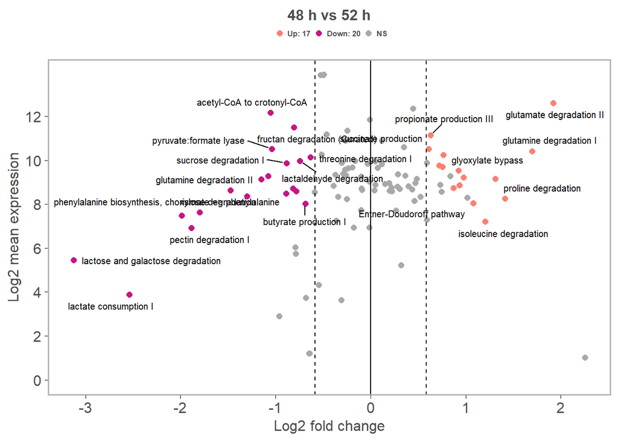

```r
p.v1 <- ggmaplot(sigtab.a, main = expression("YES" %->% "NO"),
                 fdr = 0.01, fc = 1.5, size = 2,
                 palette = c("#fb8072","#C71585", "darkgray"),
                 genenames= as.vector(sigtab.a$Names),
                 top= 40,
                 legend = "top",
                 font.label = 8,
                 font.legend = "bold",
                 font.main = "bold",
                 ggtheme = theme_syncom()) + ggtitle("48 h vs 52 h") + coord_flip()

#ggsave("results/figures/supp_gmm_deseq_change_a.pdf", height = 5, width = 8)
#ggsave("results/figures/supp_gmm_deseq_change_a.png", height = 5, width = 8, dpi=600)
p.v1
```

Compare 52h with 56h

```r
gmm.ps.b <- subset_samples(gmm.ps, Time_hr %in% c(52,56))
diagdds.b = phyloseq_to_deseq2(gmm.ps.b, ~ Time_hr )
diagdds.b = DESeq(diagdds.b, test="Wald", fitType="parametric")
res.b = results(diagdds.b, cooksCutoff = FALSE)

sigtab.b <- as.data.frame(res.b)
# read from previous
module_names <- module_df %>% distinct(Names, Module)


sigtab.b$Module <- rownames(sigtab.b)
sigtab.b <- sigtab.b %>% full_join(module_names)
```

```r
p.v2 <- ggmaplot(sigtab.b, main = expression("YES" %->% "NO"),
                 fdr = 0.01, fc = 1.5, size = 2,
                 palette = c("#fb8072","#C71585", "darkgray"),
                 genenames= as.vector(sigtab.b$Names),
                 top= 40,
                 legend = "top",
                 font.label = 8,
                 font.legend = "bold",
                 font.main = "bold",
                 ggtheme = theme_syncom()) + ggtitle("52 h vs 56 h") + coord_flip()
```

Compare 240h with 248h

```r
gmm.ps.c <- subset_samples(gmm.ps, Time_hr %in% c(240,248))
diagdds.c = phyloseq_to_deseq2(gmm.ps.c, ~ Fasting )
diagdds.c = DESeq(diagdds.c, test="Wald", fitType="parametric")
res.c = results(diagdds.c, cooksCutoff = FALSE)

sigtab.c <- as.data.frame(res.c)
# read from previous
module_names <- module_df %>% distinct(Names, Module)


sigtab.c$Module <- rownames(sigtab.c)
sigtab.c <- sigtab.c %>% full_join(module_names)
```

```r
p.v3 <- ggmaplot(sigtab.c, main = expression("YES" %->% "NO"),
                 fdr = 0.01, fc = 1.5, size = 2,
                 palette = c("#fb8072","#C71585", "darkgray"),
                 genenames= as.vector(sigtab.c$Names),
                 top= 40,
                 legend = "top",
                 font.label = 8,
                 font.legend = "bold",
                 font.main = "bold",
                 ggtheme = theme_syncom()) + ggtitle("240 h vs 248 h")+ coord_flip()
```

Compare 248h with 264h

```r
gmm.ps.d <- subset_samples(gmm.ps, Time_hr %in% c(248,264))
diagdds.d = phyloseq_to_deseq2(gmm.ps.d, ~ Fasting )
diagdds.d = DESeq(diagdds.d, test="Wald", fitType="parametric")
res.d = results(diagdds.d, cooksCutoff = FALSE)

sigtab.d <- as.data.frame(res.d)
# read from previous
module_names <- module_df %>% distinct(Names, Module)


sigtab.d$Module <- rownames(sigtab.d)
sigtab.d <- sigtab.d %>% full_join(module_names)
```

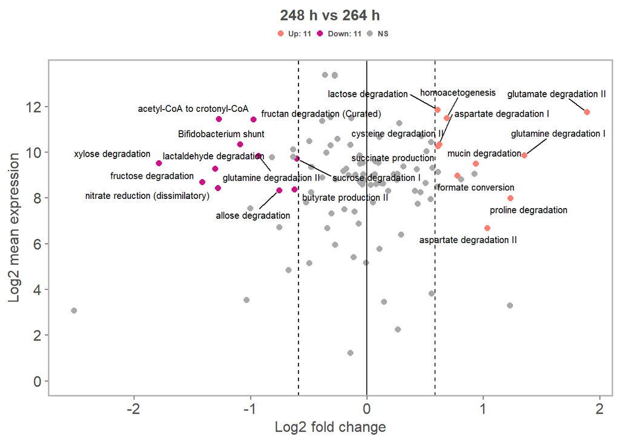

```r
p.ms <- ggmaplot(sigtab.d, main = expression("YES" %->% "NO"),
                 fdr = 0.01, fc = 1.5, size = 2,
                 palette = c("#fb8072","#C71585", "darkgray"),
                 genenames= as.vector(sigtab.d$Names),
                 top= 40,
                 legend = "top",
                 font.label = 8,
                 font.legend = "bold",
                 font.main = "bold",
                 ggtheme = theme_syncom()) + ggtitle("248 h vs 264 h")+ coord_flip()
p.ms
```

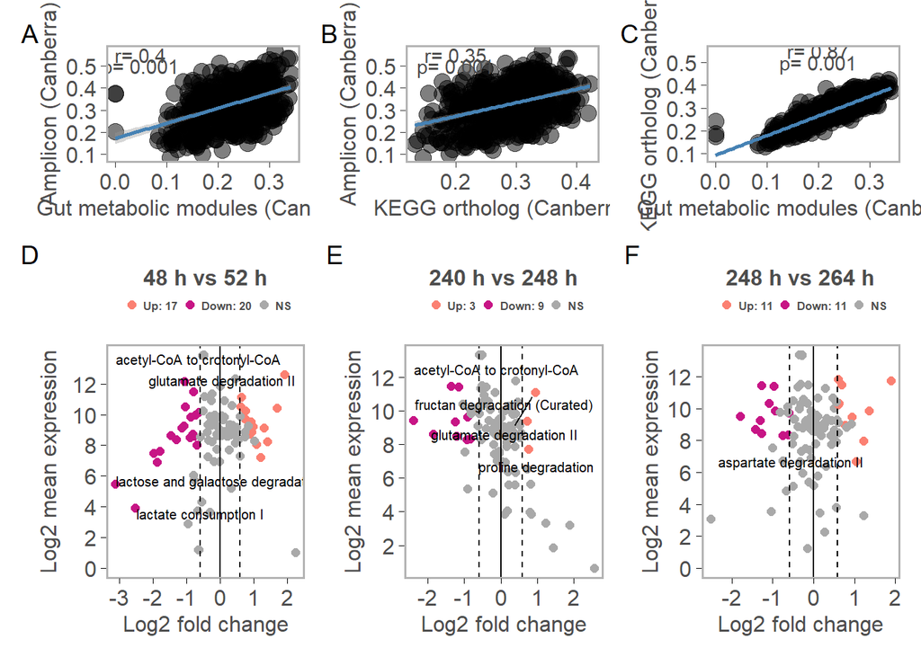

```r
maplots<- p.v1 + p.v3 + p.ms +  plot_layout(guides = "keep")

#comm_ords_plots | maplots  +  plot_layout(guides = "keep",widths = c(1,3)) + plot_annotation(tag_levels = "A")

mantel_plot / maplots  +  plot_layout(guides = "keep",heights = c(1,2)) + plot_annotation(tag_levels = "A")
```

```r
ggsave("ms/modules/figures/01_gmm_diff_analysis.pdf", height = 10, width = 14)
ggsave("ms/modules/figures/01_gmm_diff_analysis.png", height = 10, width = 14, dpi=600)
```

save excel file

```r
library("xlsx")
# Write the first data set in a new workbook
write.xlsx(sigtab.a, file = "ms/modules/tables/gmm_deseq_results.xlsx",
           sheetName = "48hvs52h", append = FALSE)
# Add a second data set in a new worksheet
write.xlsx(sigtab.b, file = "ms/modules/tables/gmm_deseq_results.xlsx",
           sheetName="52hvs56h", append=TRUE)
# Add a third data set
write.xlsx(sigtab.c, file = "ms/modules/tables/gmm_deseq_results.xlsx",
           sheetName="240hvs248h", append=TRUE)
write.xlsx(sigtab.b, file = "ms/modules/tables/gmm_deseq_results.xlsx",
           sheetName="248hvs264h", append=TRUE)



# Write the first data set in a new workbook
write.table(sigtab.a, file = "ms/modules/tables/gmm_deseq_results_48hvs52h.txt",
            sep="\t")
# Add a second data set in a new worksheet
write.table(sigtab.b, file = "ms/modules/tables/gmm_deseq_results_52hvs56h.txt",
            sep="\t")
# Add a third data set
write.table(sigtab.c, file = "ms/modules/tables/gmm_deseq_results_240hvs248h.txt",
            sep="\t")
write.table(sigtab.b, file = "ms/modules/tables/gmm_deseq_results_248hvs264h.txt",
            sep="\t")
```

## Niche overlap

Next, to investigate whether the niche partitioning suggested by 16S rRNA gene based compositional analysis can be observed at transcriptional level in individual taxa, we calculated pairwise niche overlap for each of the timepoints. A lower niche overlap would suggest higher niche segregation and vice-versa. We used the gut metabolic module framework in which we used metabolic module expression as quantitative traits for calculation of niche overlap index. We use an approach described previously by [Mouillot D., et al. 2005](https://link.springer.com/content/pdf/10.1007/s00442-005-0151-z.pdf).  
The niche overlap index decribed by Mouillot D., et al. can be used on quantitative measures of traits. Especially, because it is non-parametric and assumes no normality in trait values. In our case, gut metabolic module abundances will be treated as traits and expression values as quantitative measures.

In the table below, you can see manual classification of traits.

```r
gmm <- SyncomGMM
gmm$trait_abund <- ceiling(gmm$value)
gmm$sam_id <- paste0(gmm$Rep,"T",gmm$TimePoint)

#import trophic level classification.

trp_lev <- read.table("../data/curated_gmm_trophic_levels.txt", header = T, sep = "\t")
DT::datatable(trp_lev)
```

|  | module_id | module_name | category_1 | category_2 | category_3 | note | trophic_included | trophic_level | trophic_class | trophic_guild |
| --- | --- | --- | --- | --- | --- | --- | --- | --- | --- | --- |
| 1 | MF0001 | arabinoxylan degradation | carbohydrate degradation | polysaccharide_degradation | polysaccharide degradation | degradation | yes | 1 | primary_consumer | trophic_guild_1 |
| 2 | MF0002 | fructan degradation (Curated) | carbohydrate degradation | polysaccharide_degradation | polysaccharide degradation | degradation | yes | 1 | primary_consumer | trophic_guild_1 |
| 3 | MF0003 | pectin degradation I | carbohydrate degradation | polysaccharide_degradation | polysaccharide degradation | degradation | yes | 1 | primary_consumer | trophic_guild_1 |
| 4 | MF0004 | pectin degradation II | carbohydrate degradation | polysaccharide_degradation | polysaccharide degradation | degradation | yes | 1 | primary_consumer | trophic_guild_1 |
| 5 | MF0005 | starch degradation | carbohydrate degradation | polysaccharide_degradation | polysaccharide degradation | degradation | yes | 1 | primary_consumer | trophic_guild_1 |
| 6 | MF0006 | lactose degradation | carbohydrate degradation | simple_carb_degradation | disaccharide degradation | degradation | yes | 2 | secondary_consumer | trophic_guild_2 |
| 7 | MF0007 | lactose and galactose degradation | carbohydrate degradation | simple_carb_degradation | disaccharide degradation | degradation | yes | 2 | secondary_consumer | trophic_guild_2 |
| 8 | MF0008 | maltose degradation | carbohydrate degradation | simple_carb_degradation | disaccharide degradation | degradation | yes | 2 | secondary_consumer | trophic_guild_2 |
| 9 | MF0009 | melibiose degradation | carbohydrate degradation | simple_carb_degradation | disaccharide degradation | degradation | yes | 2 | secondary_consumer | trophic_guild_2 |
| 10 | MF0010 | sucrose degradation I | carbohydrate degradation | simple_carb_degradation | disaccharide degradation | degradation | yes | 2 | secondary_consumer | trophic_guild_2 |

[output cut: 134 more lines]

### Quantify niche overlap

I will use only those GMMs that are either degradation or consumption.  
In order to identify temporal variation in niche behavior, I will calculate pairwise overlap between taxa for each of the 12 time points for which we have RNASeq data.

```r
# read in the nichoverlap function
#https://github.com/umr-marbec/nicheoverlap/blob/master/nicheoverlap.R

#source("codes/niche_overlap.R")

#trp_lev_1 <- subset(trp_lev, trophic_class== "primary_consumer")$module_id
#get module ids for those gmms that are either degradation or consuption
trp_lev_1 <- subset(trp_lev, trophic_included== "yes")$module_id

# keep those that are either degradation or consuption
gmm_lev_1 <- subset(gmm, ModuleID %in% trp_lev_1)
# Now will keep only those whose abundance is more that 10 by convertin these to zeros to avoid error with bandwidth
# arrange by timepoint
gmm_lev_2 <-gmm_lev_1 %>% arrange(TimePoint)
#gmm_lev_1 <- subset(gmm_lev_1, TimePoint <=28)
t <- NULL # to avoid any issues
niche_op <- c() # final df with all pairwise values for all time points
all_nop <- list() # for every timepoint create a list
for (t in unique(gmm_lev_2$TimePoint)){
  gmm_1 <- gmm_lev_2 %>%
    filter(TimePoint == t) %>%
    group_by(ModuleID, Taxon) %>%
    summarise(trait_abund=mean(value))%>% # mean of three bioreactors
    pivot_wider(id_cols = ModuleID,
                names_from = Taxon,
                values_from = "trait_abund") %>%
    mutate_if(is.numeric, ~replace(., is.na(.), 0))

  gmm.mat <- data.matrix(gmm_1)
  #str(gmm_24h.mat)
  #spps <- colnames(gmm.mat[,-1])
  hold_mat <- matrix(NA, ncol(gmm.mat[,-1]), ncol(gmm.mat[,-1])) # empty matrix to hold pariwise values
  rownames(hold_mat) <- colnames(gmm.mat[,-1])
  colnames(hold_mat) <- colnames(gmm.mat[,-1])
  #trait <-
  trait <- gmm.mat[,1] # get trait names
  pair <- gmm.mat[,-1] # get trait abundances
  pair = pair[ rowSums(pair) >=50, ] # remove traits with less than 50 counts
  pair = pair[ ,colSums(pair) >=50] # remove taxa with less than 50 counts
  for (varname in colnames(pair)) {

    for (lev in colnames(pair)) {

      xvec <- pair[, varname]
      yvec <- pair[, lev]
      if (identical(xvec,yvec)){
        hold_mat[varname, lev]<-1 # place holder
      } else{
        hold_mat[varname, lev] <- niche_overlap(cbind(trait,xvec,yvec), graph=F)
      }
      hold_mat_df <- reshape2::melt(hold_mat) #long df
      hold_mat_df$t <- t #add current time point
    }

  }
  all_nop[[t]] <- hold_mat_df #populate list
  niche_op <- dplyr::bind_rows(all_nop) # bind all tips
}

#unique(niche_overlap$t)
colnames(niche_op) <- c("taxon_1", "taxon_2", "niche_overlap","time")
niche_overlap_fil <- niche_op
# filter out self overlaps
niche_overlap_fil <-  niche_overlap_fil %>%
  mutate(niche_overlaps = ifelse(niche_overlap_fil$taxon_1==niche_overlap_fil$taxon_2, NA,niche_overlap_fil$niche_overlap)) %>% select(-niche_overlap)
#head(niche_overlap_fil)

niche_overlap_fil <- niche_overlap_fil %>%
  mutate(dist_val= ifelse(niche_overlaps >= 0.25 & niche_overlaps <= 0.75, "medium 0.25-0.75", ifelse(niche_overlaps < 0.25, "low < 0.25", ifelse(niche_overlaps >0.75, "high >0.75", ""))))

head(niche_overlap_fil)
```

```
##                        taxon_1               taxon_2 time niche_overlaps
## 1        Agathobacter_rectalis Agathobacter_rectalis   24             NA
## 2           Bacteroides_ovatus Agathobacter_rectalis   24          0.864
## 3    Bacteroides_xylanisolvens Agathobacter_rectalis   24          0.911
## 4 Bifidobacterium_adolescentis Agathobacter_rectalis   24          0.951
## 5                Blautia_obeum Agathobacter_rectalis   24          0.847
## 6          Eubacterium_siraeum Agathobacter_rectalis   24          0.623
##           dist_val
## 1             <NA>
## 2       high >0.75
## 3       high >0.75
## 4       high >0.75
## 5       high >0.75
## 6 medium 0.25-0.75
```

### Visualize temporal niche overlap

```r
niche_overlap_fil <- niche_overlap_fil %>%
  arrange(time)
niche_overlap_fil$niche_seggregation <- (1- niche_overlap_fil$niche_overlaps)
niche_overlap_fil$time_hr <- paste0(niche_overlap_fil$time, " ", "h")

niche_overlap_fil <- niche_overlap_fil %>%
  arrange(time) %>%
  mutate_at(vars(time_hr), funs(factor(., levels=unique(.))))
```

```r
temp_nop_plot <- ggplot(niche_overlap_fil, aes(x = niche_overlaps,y=taxon_2)) +
  #geom_density_ridges(aes(fill = taxon_2), alpha=0.6) +
  geom_rect(xmin = 0.25, xmax = 0.75, ymin = -Inf, ymax = Inf, fill = 'grey90', alpha = 0.05)+
  stat_density_ridges(quantile_lines = TRUE, quantiles = 2, aes(fill=taxon_2), alpha=0.6) + facet_wrap(~time_hr)+
  scale_fill_manual("Species",values = syncom_colors("BacterialSpecies")) +
  theme_syncom()+
  geom_vline(xintercept = 0.5, lty=2) + xlim(0,1)  +
  theme(axis.ticks.y = element_blank(),
        axis.text.y = element_blank(),
        legend.text = element_text(size=10)) + xlab("Niche Overlap") + theme(legend.position="top") + ylab(" ")

ggsave("ms/modules/figures/02_nop_temporal.pdf", height = 8, width = 10)
#ggsave("../scratch/niche_overlap_temporal.pdf", height = 10, width = 16)
ggsave("ms/modules/figures/02_nop_temporal.png", height = 12, width = 14, dpi = 600)
```

Following the peaks for taxa at different timepoints, we see movement in overlaps. The dotted line represents a niche overlap values of 0.5 (min is 0 and max is 1). A noteable trend is higher overlap (most peaks >0.5) in fasting samples. While spikes in carbohydrates results is broader spread in niche overlap values. Carbs support co-existence, which is expected as niches are created by diet.

So over time how are pair-wise niche overlap distributed? Here, we plot density estimates for niche pair-wise niche overlap values to compared each strain with the rest of the strains in the community.

```r
spps_pair <- ggdensity(niche_overlap_fil, "niche_overlaps",
                       color = "taxon_1",
                       palette = syncom_colors("BacterialSpecies"),
                       facet.by = "taxon_2", scales="free", size=0.5,
                       rug = TRUE) +
  #geom_density_ridges(aes(fill = taxon_2), alpha=0.6) +
  theme_bw()  +
  theme(#axis.ticks.y = element_blank(),
    strip.text = element_text(size=9,face="italic"),
    axis.text = element_text(size=10),
    #axis.text.y = element_blank(),
    legend.text = element_text(size=10,face="italic")) +
  xlim(c(0,1)) + xlab("Niche Overlap") #+
#  geom_vline(xintercept = 0.5, lty=3,  alpha=0.5, color="grey70")


ggsave("ms/modules/figures/02a_density_niche_overlap_temporal_pairwise.pdf", height = 8, width = 11)
#ggsave("../scratch/niche_overlap_pairwise.pdf", height = 10, width = 16)
ggsave("ms/modules/figures/02a_density_niche_overlap_temporal_pairwise.png", height = 12, width = 14, dpi = 600)
```

The polysaccharide degraders, *B. xylanisolvens* with *A. muciniphila*, *A. rectalis* with *B. adolescentis*, *S. variabile* with *F. prausnitzii* showed comparatively higher niche overlap than non-degraders. However, *C. catus* and *A. soehngenii* showed low niche overlap. *C. catus* more often than not showed low niche overlap with all the other 15 strains in the community. Interestingly, niche overlap patterns of two *Bacteroides* species were similar to each other, while the two *Blautia* species had variabile patterns of niche overlap. Moreover, the niche overlap values showed temporal variation, suggesting transcriptional response to changing environment. Most fasting timepoints showed larger spread in niche values of bacteria from *Firmicutes* phylum. Thus, nutrient periodicity together with temporal niche partitioning are process driving the co-existence of all the 16 strains during the entire course of this experiment.

```r
bacteroides <- subset(niche_overlap_fil, taxon_2 %in% c("Bacteroides_ovatus", "Bacteroides_xylanisolvens")) %>% group_by(time, taxon_2) %>% summarise(nop=mean(niche_overlaps, na.rm = T))
#DT::datatable(bacteroides)

blautia <- subset(niche_overlap_fil, taxon_2 %in% c("Blautia_obeum", "Blautia_hydrogenotrophica"))%>% group_by(time, taxon_2) %>% summarise(nop=mean(niche_overlaps, na.rm = T))
DT::datatable(blautia)
```

|  | time | taxon_2 | nop |
| --- | --- | --- | --- |
| 1 | 24 | Blautia_obeum | 0.756928571428571 |
| 2 | 24 | Blautia_hydrogenotrophica |  |
| 3 | 28 | Blautia_obeum | 0.781714285714286 |
| 4 | 28 | Blautia_hydrogenotrophica |  |
| 5 | 32 | Blautia_obeum | 0.791571428571429 |
| 6 | 32 | Blautia_hydrogenotrophica |  |
| 7 | 48 | Blautia_obeum | 0.827833333333333 |
| 8 | 48 | Blautia_hydrogenotrophica |  |
| 9 | 52 | Blautia_obeum | 0.789928571428571 |
| 10 | 52 | Blautia_hydrogenotrophica |  |

[output cut: 14 more lines]

## Trophic levels within the MDb-MM and realized niches of core bacteria

The presence of low niche overlap indicated the presence of trophic levels within the minimal microbiome. The metabolic flow and biomass distribution within the gut is largely driven by bacteria with specialized molecular machinery capable of degrading complex carbon sources. The action of polysaccharide degraders (primary consumers) results in niche construction that may be dependent on the source as well as their metabolic pathways. Consequently, leading to formation of a hierarchal organization within the community into trophic levels. Here, based on metatranscriptomic assignment of gut metabolic modules, we identify four trophic levels in agreement with previous computation simulations.

### Trophic niches

```r
gmm <- SyncomGMM

gmm$Taxon <- gsub("Flavonifractor_plautiia", "Flavonifractor_plautii", gmm$Taxon)
gmm$sample_id <- paste0(gmm$Rep,"T",gmm$TimePoint)

trp_lev <- read.table("../data/curated_gmm_trophic_levels.txt", header = T, sep = "\t")

gmm_trp <- gmm
names(gmm_trp)[names(gmm_trp) == "ModuleID"] <- "module_id"
gmm_trp <- left_join(gmm_trp, trp_lev)
library(ggtern)
gmm_trp_guild <- gmm_trp %>%
  filter(trophic_guild!= "na") %>%
  group_by(Taxon, TimePoint, trophic_guild) %>%
  summarise (n = mean(value)) %>%
  filter(n >=5) %>%
  mutate(freq = n / sum(n))
```

```r
gmm_trp_ldf <- gmm_trp_guild %>%
  pivot_wider(id_cols = c(Taxon,TimePoint),
              names_from = trophic_guild,
              values_from = freq)  %>%
  replace(is.na(.), 0)

metld <- meta(SyncomFiltData) %>%
  select(Time_hr_num, Fasting, Pertubation, RNASeq)%>%
  filter(RNASeq=="YES") %>%
  distinct(Time_hr_num, Fasting, Pertubation)

colnames(metld) <- c("TimePoint", "Fasting", "Pertubation")

gmm_trp_ldf.2 <- merge(gmm_trp_ldf, metld, by = "TimePoint")
# Build and Render the Plot
gmm_trp_ldf.2 = gmm_trp_ldf.2[with(gmm_trp_ldf.2, order(-trophic_guild_2)), ]

gmm_trp_ldf.2$Taxon <- gsub("_", " ", gmm_trp_ldf.2$Taxon)

triplot_trp_niche <- ggtern(data = gmm_trp_ldf.2, aes(x = trophic_guild_1, y = trophic_guild_2, z = trophic_guild_3)) +
  #the layers
  geom_mask()  +
  geom_Tline(Tintercept=.5, colour='grey50') +
  geom_Lline(Lintercept=.5, colour='grey50') +
  geom_Rline(Rintercept=.5, colour='grey50') +
  #geom_confidence_tern(alpha=0.7,size=1, aes(colour=Taxon)) + #MASK UNDER POINTS
  geom_point(aes(color = Taxon, shape=Fasting), size=4, alpha=0.5) +
  scale_color_manual(values=syncom_colors2("BacterialSpecies")) + #theme tweaks
  theme_bw() + scale_shape_manual(values = c(15,16,17,18))+
  theme_showarrows() +
  theme(
    panel.background = element_rect(fill = "white"),
    # panel.border = element_rect(size = 1),
    # plot.margin = margin(0.3, 0.3, 0.3, 0.3, "cm"),
    panel.grid.major = element_blank(),
    panel.grid.minor = element_blank(),
    panel.spacing = unit(0.5, "line"),
    legend.text = element_text(face="italic"),
    # axis.ticks = element_blank(),
    axis.text = element_text(size = 8),
    axis.title = element_text(size = 8),
    strip.background = element_blank())

ggsave("ms/modules/figures/03_ternary_plot.pdf", height = 6, width = 12)
ggsave("ms/modules/figures/03_ternary_plot.png", height =6, width = 12, dpi = 600)
```

### Trophic guild contribution

```r
gmm_trp_guild <- gmm_trp %>%
  filter(trophic_guild!= "na") %>%
  group_by(Taxon, TimePoint, trophic_guild) %>%
  summarise (n = mean(value)) %>%
  filter(n >=5) %>%
  mutate(freq = n / sum(n))
```

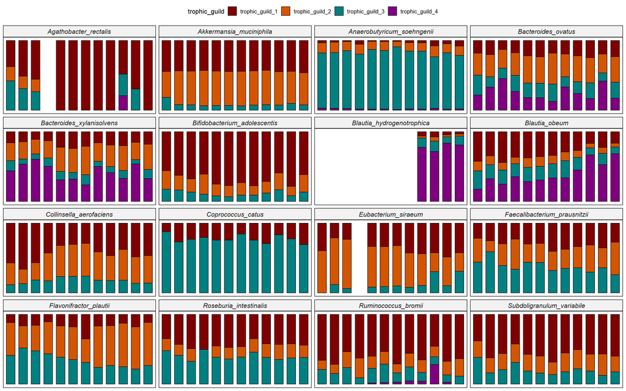

Trophic guild contribution

```r
col_trp <- c(trophic_guild_1="#800000",
             trophic_guild_2= "#d45500",
             trophic_guild_3="#008080",
             trophic_guild_4= "#800080")

ggbarplot(gmm_trp_guild,
          x = "TimePoint",
          y= "freq",
          facet.by = "Taxon",
          fill = "trophic_guild",
          palette = col_trp)  +
  theme(legend.position = "top")+
  theme(#axis.ticks.y = element_blank(),
    strip.text = element_text(size=12,face="italic"),
    #axis.text = element_text(size=10),
    legend.text = element_text(size=10))
```

```r
ggsave("ms/modules/figures/04_trophic_guild_contribution.pdf", height = 10, width = 14)
ggsave("ms/modules/figures/04_trophic_guild_contribution.png", height = 10, width = 14, dpi = 600)
```

## Specific Metabolic Contribuitions

```r
gmm <- SyncomGMM
gmm$sample_id <- paste0(gmm$Rep,"T",gmm$TimePoint)
gmm$Taxon <- gsub("_", " ", gmm$Taxon)

# convert module counts to proportions
gmm.rel <- gmm %>%
  group_by(ModuleID, Module, sample_id, Taxon) %>%
  filter(value >=10) %>%
  summarise (n = value) %>%
  mutate(freq = n / sum(n))
# create seperate cols for Bioreactors and Time point
gmm.rel <- gmm.rel %>%
  separate(col = sample_id,
           into = c("Bioreactor", "Time"),
           sep = "T")

gmm.rel$Time <- as.numeric(gmm.rel$Time)
gmm.rel$Taxon <- gsub("_", " ", gmm.rel$Taxon)
```

### Trophic level 1/Primary level

Metabolic modules for mucin, pectin, inulin, starch and arabinoxylan form the first trophic level. *A. muciniphila* predominantly occupied a specialized niche for mucin consumption compared to *B. xylanisolvens* which is not known for consuming mucin. Pectin degradation was identified in *F. prausnitzii*, *B. ovatus* and *B. xylanisolvens*. Inulin degradation was relatively predominant in *B. adolescentis*, compared to *R. bromii*, *B. obeum*, *F. prausniztii* and *S. variabile*. Starch degradation was identified in *R. bromii*, *B. ovatus* and *B. xylanisolvens*. *B. hydrogenotrophica* was introduced at 152h into the minimal microbiome and showed active expression of starch degradation module at 176h, 240h, 248 and 264h. Xylan degradation activity was predominantly observed in S. variabile. The observation for xylan degradation was unexpected because in our previous study with 10-species diet based minimal microbiome, we did not observe high expression of gene involved in xylan degradation in *S. variable*. The observation of transcriptional activity at metabolic module level likely suggests a more concerted effort by multiple species to breakdown/utilize complex polysaccharides rather than just a single species.

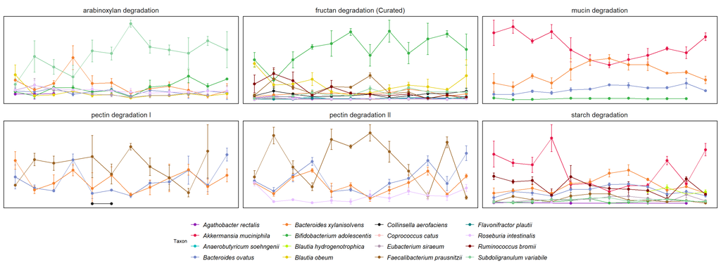

```r
module.fiber <- subset(gmm.rel, Module == "pectin degradation I" | Module == "pectin degradation II"| Module == "fructan degradation (Curated)"| Module == "arabinoxylan degradation" | Module =="starch degradation" | Module == "mucin degradation")
#module.fiber[module.fiber == 0]<- NA
#str(module.fiber)


p.fiber <- ggline(module.fiber, "Time", "freq",
                  color = "Taxon",
                  facet.by = "Module",
                  add="mean_sd",
                  palette = syncom_colors2("BacterialSpecies"),
                  scales="free",
                  ylab = "Relative proportions \n(metatranscriptomics)", legend = "bottom")
p.fiber <- p.fiber + theme(#axis.ticks.y = element_blank(),
  panel.background = element_rect(fill = "white"),
  panel.grid.major = element_blank(),
  panel.spacing = unit(0.5, "line"),
  panel.grid.minor = element_blank(),
  strip.text = element_text(size=11),
  #axis.text.y = element_text(size=8),
  #axis.text.x = element_text(size=9),
  strip.background = element_blank(),
  legend.title = element_text(size=8),
  legend.position="bottom",
  legend.text = element_text(face="italic"))


p.fiber
```

```r
ggsave("ms/modules/figures/05_trophic_level_1.pdf", height = 6, width = 14)
ggsave("ms/modules/figures/05_trophic_level_1.png", height = 6, width = 14, dpi=600)
```

KOs linked to GMMs

```r
#arabinoxylan degradation
arbxyl <- c("K01209",   "K15921",   "K01181",   "K01198",   "K15531",   "K18205")

# fructan degradation (curated, FOS)
frctn <- c("K01193",    "K03332", "K00847", "K10117" ,"K10118", "K10119", "K10112")

# pectin degradation I
pect_a <- c("K01051", "K01184","K01213",    "K18650")

# pectin degradation II
pect_b <- c("K01051","K18650","K01728","K19551",    "K01731" ,"K01730","K01815","K00874","K01625",  "K17463")

# starch degradation
strch <- c("K01176",    "K07405",   "K05343", "K01200", "K01208","K00688",  "K16153",   "K00705",   "K01187",   "K15922",   "K01178",   "K01182")

# mucin degradation
mucin <- c("K01186", "K05970", "K01132",    "K01135",   "K01137",   "K01205", "K01207", "K12373",   "K14459", "K01205", "K01207",   "K12373",   "K01227", "K13714", "K01206")
```

using the raw kegg counts now check for individual KO abundances

```r
# since KO are part ofmultiple table the raw file stored on syncom has repitative values
# we choose only unique

kegg_ko <- SynComRNAKEGG %>%
  distinct(LocusTag,.keep_all = T)

# assign rownames
rownames(kegg_ko) <- kegg_ko$LocusTag

# convert the raw counts to counts per million to account for libray sizes
# the samples start from column 3 to 38
kegg_ko_cpm <- as.data.frame(cpm(kegg_ko[,3:38], log = T))
# add new column to join with original table
kegg_ko_cpm$LocusTag <- rownames(kegg_ko_cpm)

KO_gene <- select(kegg_ko, KOGeneName, KO,LocusTag, BacterialStrain)

# join the two tables
ko_cmp_cnts <- merge(KO_gene,kegg_ko_cpm, by="LocusTag")

#readr::write_excel_csv2(ko_cmp_cnts, "results/tables/keeg_cpm_ko_pwy.csv")

# now choose only those KO that are part of the trophic level 1 modules
all <- c(arbxyl,frctn,pect_a,pect_b,strch,mucin)

trp_1_kos <- subset(ko_cmp_cnts, KO %in% all) # the numbers will be different because not all ko as detected in transcriptomics

# convert to long format
trp_ldf <- melt(trp_1_kos)
```

```r
# fix this particular sample name for numeric conversion
trp_ldf$variable <- gsub("74A5", "74.5", trp_ldf$variable)

# now we need to seperate cols for bioreactors and time points.
trp_ldf <- trp_ldf %>%
  separate(col = variable, # holds the samples names
           into = c("Bioreactor", "Time"),
           sep = "T")

trp_ldf$Time <- as.numeric(trp_ldf$Time)

# Now add a new column as a heirarchy for KO-Module
# arbxyl,frctn,pect_a,pect_b,strch
trp_ldf <- trp_ldf %>%
  mutate(metab_module= ifelse(KO %in% arbxyl, "Arabinoxylan degradation",
                              ifelse(KO %in% frctn, "Fructan degradation",
                                     ifelse(KO %in% pect_a, "Pectin degradation I",
                                            ifelse(KO %in% pect_b, "Pectin degradation II",
                                                   ifelse(KO %in% strch, "Starch degradation",
                                                          ifelse(KO %in% mucin, "Mucin degradation","Unkwn")))))))

#head(trp_ldf)
# create a new column to hold modified bacterial names

trp_ldf$Taxon <- gsub("_", " ", trp_ldf$BacterialStrain)


trp_ldf <- trp_ldf %>%
  mutate(Bioreactor= ifelse(Bioreactor == "F5", "Bioreactor A",
                            ifelse(Bioreactor == "F6", "Bioreactor B",
                                   ifelse(Bioreactor == "F8", "Bioreactor C","Unkwn"))))

# Change name of lach spps
trp_ldf$Taxon <- gsub("Lachnospiraceae_bacterium", "Flavonifractor_plautii", trp_ldf$Taxon)

# now we start plotting these data
```

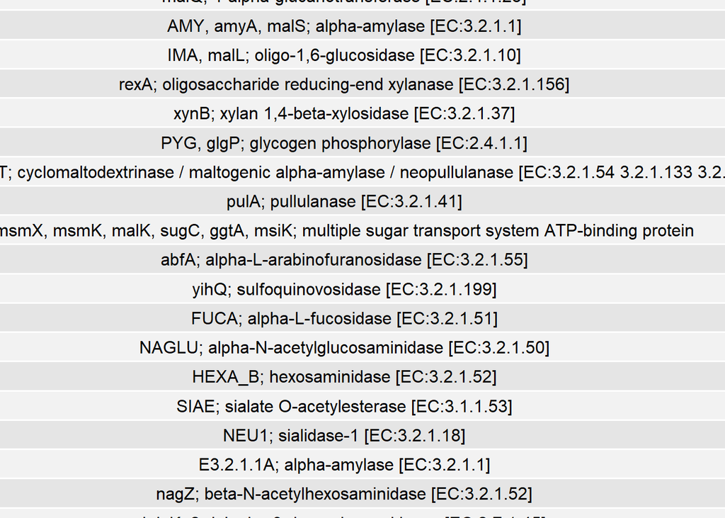

```r
# reorder(OTU,var)
trp_ldf$metab_module <- factor(trp_ldf$metab_module, levels= c("Fructan degradation","Starch degradation","Arabinoxylan degradation", "Mucin degradation", "Pectin degradation II","Pectin degradation I" ))

tab <- gridExtra::tableGrob(trp_ldf %>%
                              distinct(KO, KOGeneName))
plot(tab)
```

### Fructan KOs

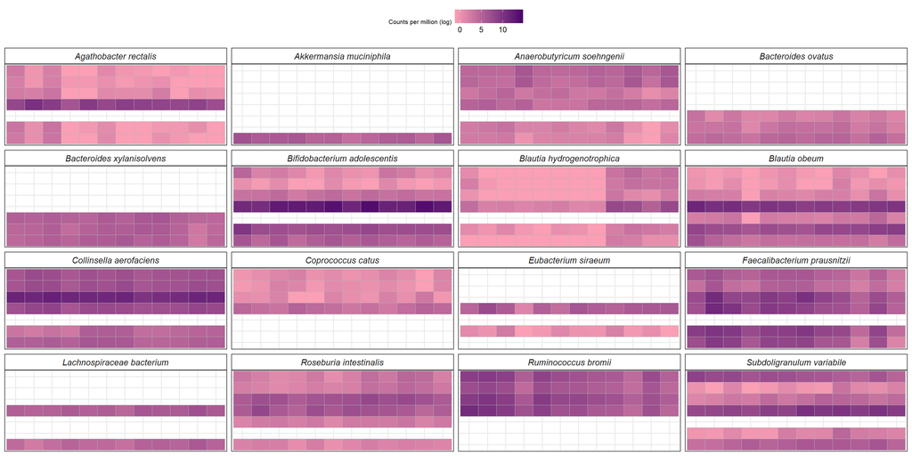

```r
fructan_plot <- trp_ldf %>%
  filter(metab_module == "Fructan degradation") %>%
  ggplot(aes(as.factor(Time),KO)) +
  geom_tile(aes(fill=value), color="grey70") +
  facet_wrap(~Taxon) + ylab("KOs (Fructan degradation)") +
  xlab("Time (h)") +
  scale_fill_continuous("Counts per million (log)",
                        low = "#fa9fb5", high = "#49006a") +
  rotate_x_text() +
  theme_bw() + rotate_x_text() +
  theme(#axis.ticks.y = element_blank(),
    strip.background = element_rect(fill="white"),
    strip.text = element_text(size=11, face='italic'),
    #axis.text.y = element_text(size=8),
    #axis.text.x = element_text(size=9),
    legend.title = element_text(size=8),
    legend.position="top")

fructan_plot
```

```r
ggsave("ms/modules/figures/05a_fructan_plot.pdf", height = 8, width = 12)
```

### Arabinoxylan KOs

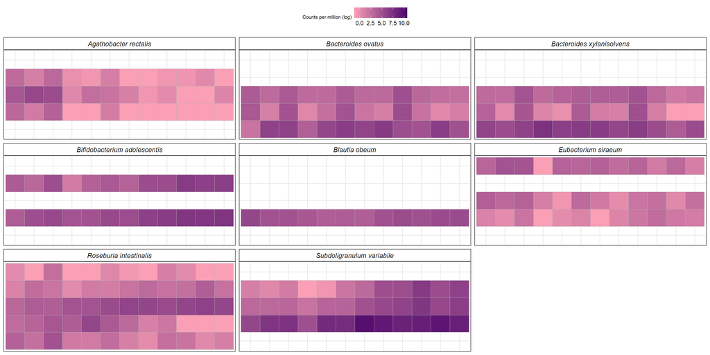

```r
arabxylan_plot <- trp_ldf %>%
  filter(metab_module == "Arabinoxylan degradation") %>%
  ggplot(aes(as.factor(Time),KO)) +
  geom_tile(aes(fill=value), color="grey70") +
  facet_wrap(~Taxon) + ylab("KOs (Arabinoxylan degradation)") +
  xlab("Time (h)") +
  scale_fill_continuous("Counts per million (log)",
                        low = "#fa9fb5", high = "#49006a") +
  theme_bw() + rotate_x_text() +
  theme(#axis.ticks.y = element_blank(),
    strip.background = element_rect(fill="white"),
    strip.text = element_text(size=11, face='italic'),
    axis.text.y = element_text(size=8),
    axis.text.x = element_text(size=9),
    legend.title = element_text(size=8),
    legend.position="top")
arabxylan_plot
```

```r
ggsave("ms/modules/figures/05a_arabinoxylan_plot.pdf", height = 6, width = 12)
```

### Pectin KOs

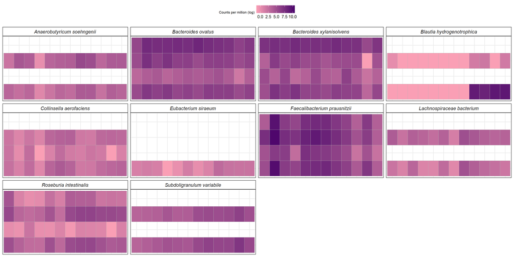

```r
pectin_plot <- trp_ldf %>%
  filter(metab_module %in% c("Pectin degradation I","Pectin degradation II")) %>%
  ggplot(aes(as.factor(Time),KO)) +
  geom_tile(aes(fill=value), color="grey70") +
  facet_wrap(~Taxon) + ylab("KOs (Pectin degradation I & II)") +
  xlab("Time (h)") +
  scale_fill_continuous("Counts per million (log)",
                        low = "#fa9fb5", high = "#49006a") +
  theme_bw() + rotate_x_text() +
  theme(#axis.ticks.y = element_blank(),
    strip.background = element_rect(fill="white"),
    strip.text = element_text(size=11, face='italic'),
    axis.text.y = element_text(size=8),
    axis.text.x = element_text(size=9),
    legend.title = element_text(size=8),
    legend.position="top")
pectin_plot
```

```r
ggsave("ms/modules/figures/05a_pectin_plot.pdf", height = 6, width = 12)
```

### Starch KOs

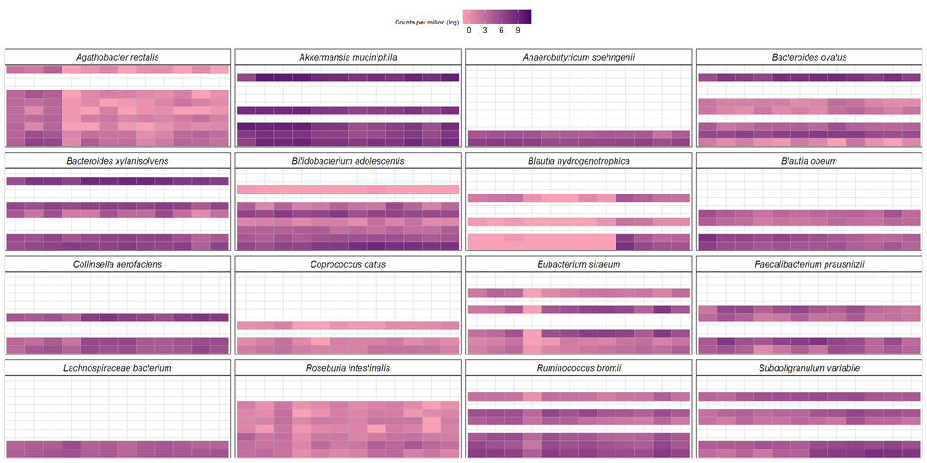

```r
starch_plot <- trp_ldf %>%
  filter(metab_module== "Starch degradation") %>%
  ggplot(aes(as.factor(Time),KO)) +
  geom_tile(aes(fill=value), color="grey70") +
  facet_wrap(~Taxon) + ylab("KOs (Starch degradation)") +
  xlab("Time (h)") +
  scale_fill_continuous("Counts per million (log)",
                        low = "#fa9fb5", high = "#49006a") +
  theme_bw() + rotate_x_text() +
  theme(#axis.ticks.y = element_blank(),
    strip.background = element_rect(fill="white"),
    strip.text = element_text(size=11, face='italic'),
    axis.text.y = element_text(size=8),
    axis.text.x = element_text(size=9),
    legend.title = element_text(size=8),
    legend.position="top")
starch_plot
```

```r
ggsave("ms/modules/figures/05a_starch_plot.pdf", height = 8, width = 12)
```

### Mucin KOs

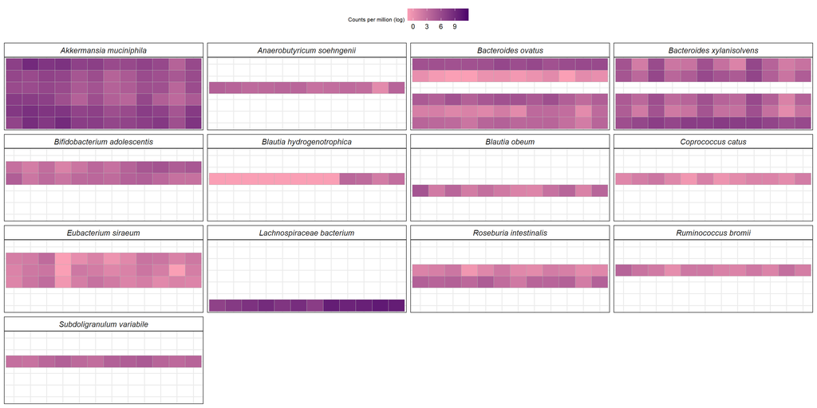

```r
mucin_plot <- trp_ldf %>%
  filter(metab_module== "Mucin degradation") %>%
  ggplot(aes(as.factor(Time),KO)) +
  geom_tile(aes(fill=value), color="grey70") +
  facet_wrap(~Taxon) +
  ylab("KOs (Mucin degradation)") +
  xlab("Time (h)") +
  scale_fill_continuous("Counts per million (log)",
                        low = "#fa9fb5", high = "#49006a") +
  theme_bw() + rotate_x_text() +
  theme(#axis.ticks.y = element_blank(),
    strip.background = element_rect(fill="white"),
    strip.text = element_text(size=11, face='italic'),
    axis.text.y = element_text(size=8),
    axis.text.x = element_text(size=9),
    legend.title = element_text(size=8),
    legend.position="top")

mucin_plot
```

```r
ggsave("ms/modules/figures/05a_mucin_plot.pdf", height = 6, width = 12)
```

## Trophic guild 2

```r
list.carbs <- c("xylose degradation", "galacturonate degradation I", "galacturonate degradation II", "lactose degradation", "maltose degradation", "arabinose degradation", "fructose degradation", "galactose degradation", "mannose degradation", "rhamnose degradation", "fucose degradation", "sucrose degradation I", "sucrose degradation II")

module.carbs <- subset(gmm.rel, Module %in% list.carbs)
#module.carbs[module.carbs ==0]<- NA

p.carbs <- ggline(module.carbs, "Time", "freq",
                  color = "Taxon",
                  facet.by = "Module",
                  add="mean_sd",
                  palette = syncom_colors2("BacterialSpecies"),
                  scales="free",
                  ylab = "Relative proportions \n(metatranscriptomics)",
                  legend = "bottom",  nrow = NULL, ncol = 2)
```

[output not shown]

[output cut: 72 more lines]

[output not shown]

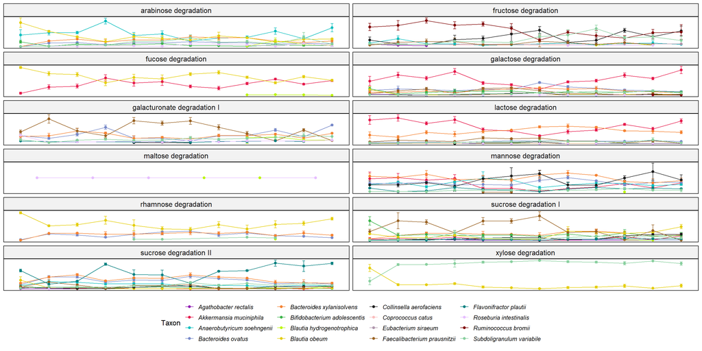

```r
p.carbs <- p.carbs + theme(legend.position="bottom",
                           legend.text = element_text(face="italic"),
                           strip.text = element_text(size = 12))
p.carbs
```

```r
ggsave("ms/modules/figures/06_trophic_level_2.pdf", height = 12, width = 14)
ggsave("ms/modules/figures/06_trophic_level_2.png", height = 12, width = 14, dpi=600)
```

## Trophic guild 3

```r
gmm.list.scfa <- c("propionate production IV (1,2-PD)","propionate production I",
                   "propionate production III",
                   "homoacetogenesis", "acetate to acetyl-CoA",
                   "acetyl-CoA to acetate", "acetate to acetyl-CoA II",
                   "lactate production","lactate consumption II",
                   "acetyl-CoA to crotonyl-CoA",
                   "lactate consumption III (lctABCDEF, Curated)",
                   "pyruvate:formate lyase", "formate conversion",
                   "Acetate synthesis IV", "Acetate synthesis II")

module.vfa <- filter(gmm.rel, Module %in% gmm.list.scfa)

p.vfa <- ggline(module.vfa, "Time", "freq",
                color = "Taxon",
                facet.by = "Module",
                add="mean_sd",
                palette = syncom_colors2("BacterialSpecies"),
                scales="free",
                ylab = "Relative proportions \n(metatranscriptomics)",
                legend = "bottom",  nrow = NULL, ncol = 2)
```

[output not shown]

[output cut: 52 more lines]

[output not shown]

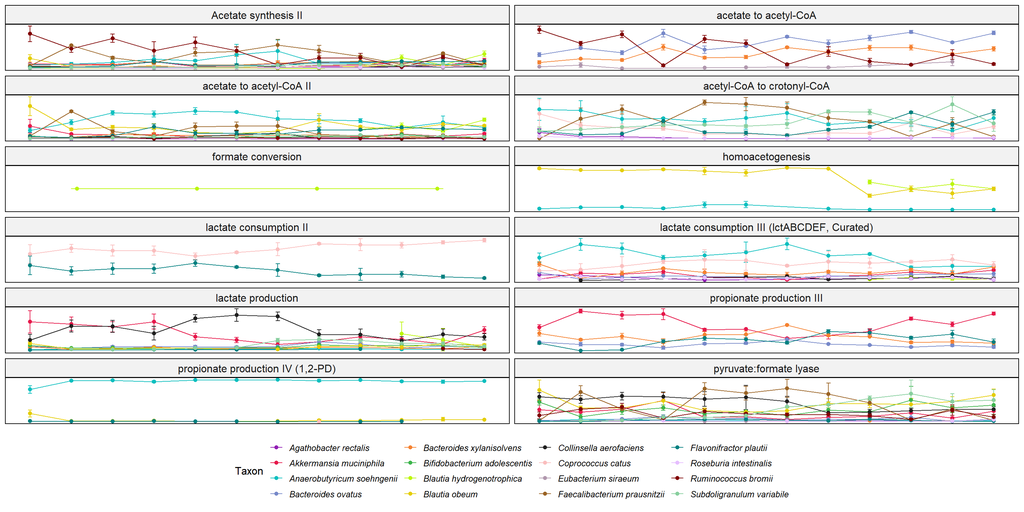

```r
p.vfa <- p.vfa + theme(legend.position="bottom",
                       legend.text = element_text(face="italic"),
                       strip.text = element_text(size = 12))
p.vfa
```

```r
ggsave("ms/modules/figures/07_trophic_level_3.pdf", height = 12, width = 14)
ggsave("ms/modules/figures/07_trophic_level_3.png", height = 12, width = 14, dpi=600)
```